# Sales Forecast

Yu Yuen Hern

2022-12-07

## Read dataset

```r
df <- readxl::read_xlsx(DATASET_PATH, sheet = "Data")
df
```

| PO Date | Year | Month | Channel | Cust ID | Item | Qty | Sales Amt |
| --- | --- | --- | --- | --- | --- | --- | --- |
| 2019-01-01 | 2019 | 1 | AH | 1300950362 | CXB02 | -30 | -8544 |
| 2019-01-01 | 2019 | 1 | AH | 1300951458 | EZA01 | 50 | 42714 |
| 2019-01-01 | 2019 | 1 | AH | 1300938625 | LSN01 | 110 | 12407 |
| 2019-01-01 | 2019 | 1 | AH | 1300942430 | LSN01 | 160 | 13824 |
| 2019-01-01 | 2019 | 1 | AH | 1300942783 | LSN01 | 199 | 10613 |
| 2019-01-01 | 2019 | 1 | AH | 1300942878 | LSN01 | 160 | 13218 |
| 2019-01-01 | 2019 | 1 | AH | 1300943166 | LSN01 | 600 | 32000 |
| 2019-01-01 | 2019 | 1 | AH | 1300943869 | LSN01 | 40 | 2240 |
| 2019-01-01 | 2019 | 1 | AH | 1300944313 | LSN01 | 170 | 9066 |
| 2019-01-01 | 2019 | 1 | AH | 1300945252 | LSN01 | 65 | 5370 |

[output cut: 990 more lines]

## Check for missing values

```r
sum(is.na(df$`Sales Amt`))
```

```
[1] 37
```

```r
df$`Sales Amt`[is.na(df$`Sales Amt`)] = 0
sum(is.na(df$`Sales Amt`))
```

```
[1] 0
```

## Plot sales over time

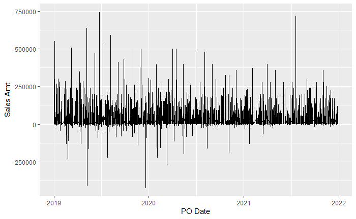

```r
p <- ggplot(df, aes(x=`PO Date`, y=`Sales Amt`)) + geom_line()
p
```

## Holt Winters

As Holt-Winters function require time series `ts` object and `ts` object only accepts evenly spaced data, we aggregate the daily data into monthly data.

```r
df <- df[c("Year", "Month", "Sales Amt")]
df
```

| Year | Month | Sales Amt |
| --- | --- | --- |
| 2019 | 1 | -8544 |
| 2019 | 1 | 42714 |
| 2019 | 1 | 12407 |
| 2019 | 1 | 13824 |
| 2019 | 1 | 10613 |
| 2019 | 1 | 13218 |
| 2019 | 1 | 32000 |
| 2019 | 1 | 2240 |
| 2019 | 1 | 9066 |
| 2019 | 1 | 5370 |

[output cut: 990 more lines]

Aggregate the data

```r
df <- df %>% group_by(Year, Month) %>% summarise(Monthly_Sales=sum(`Sales Amt`))
df
```

| Year | Month | Monthly_Sales |
| --- | --- | --- |
| 2019 | 1 | 22104774 |
| 2019 | 2 | 7888127 |
| 2019 | 3 | 13087760 |
| 2019 | 4 | 16146615 |
| 2019 | 5 | 12366224 |
| 2019 | 6 | 12824906 |
| 2019 | 7 | 12825375 |
| 2019 | 8 | 11228008 |
| 2019 | 9 | 12426177 |
| 2019 | 10 | 12607468 |

[output cut: 26 more lines]

```r
tail(unique(df$Year), 2)[1]
```

```
[1] 2020
```

Split the dataset into train (2019 and 2020) and test (2021)

```r
df_train <- subset(df, Year <= 2020)
df_test <- subset(df, Year == 2021)
```

Overall plot of data

```r
dfts <- df$Monthly_Sales %>% ts(start = c(2019, 1), end = c(2021, 12), frequency = 12)
plot(dfts)
```

[output not shown]

Convert the data into `ts` object

```r
dfts_train <- df_train$Monthly_Sales %>% ts(start = c(2019, 1), end = c(2020, 12), frequency = 12)
dfts_train
```

[output not shown]

Perform Holt-Winters fitting

```r
hw1 <- HoltWinters(dfts_train)
hw1
```

[output not shown]

Perform Holt-Winters prediction and overlay forecast on original data

```r
hw1.pred <- predict(hw1, n.ahead = 12, prediction.interval = TRUE, level = 0.95)
plot(hw1, predicted.values = hw1.pred, ylab = "Sales Amt")
```

[output not shown]

Perform Holt-Winters fitting with multiplicative seasonality

```r
hw2 <- HoltWinters(dfts_train, seasonal = "multiplicative")
hw2.pred <- predict(hw2, n.ahead = 12, prediction.interval = TRUE, level = 0.95)
plot(hw2, predicted.values = hw2.pred, ylab = "Sales Amt")
```

[output not shown]

## Using forecast library

```r
library(forecast)
```

Plot hw1 model with forecast library

```r
hw1_for <- forecast(hw1, h = 12, level = 0.95)
plot(hw1_for)
lines(hw1_for$fitted, lty=2, col="red")
```

[output not shown]

Plot hw2 model with forecast library

```r
hw2_for <- forecast(hw2, h = 12, level = 0.95)
plot(hw2_for)
lines(hw2_for$fitted, lty=2, col="red")
```

[output not shown]

## Evaluate

Firstly we want to check if there are any autocorrelation in residue.

```r
hw1_acf <- acf(hw1_for$residuals, lag.max = 12, na.action=na.pass)
```

[output not shown]

Secondly, we want to find out if the variable are independent using Ljung-Box test.

```r
Box.test(hw1_for$residuals, type="Ljung-Box")
```

[output not shown]

Thirdly, we check if the residuals are normally distributed.

```r
hist(hw1_for$residuals)
```

[output not shown]

And lastly, we check the MAPE of both Holt-Winters model.

```r
mape <- function(actual,pred){
  mape <- mean(abs((actual - pred)/actual))*100
  return (mape)
}
```

```r
mape_hw1 <- mape(df_test$Monthly_Sales, hw1.pred[,1])
mape_hw2 <- mape(df_test$Monthly_Sales, hw2.pred[,1])
cat(mape_hw1, mape_hw2)
```

[output not shown]

## Forecast 36 months (12 months of dfts_test + 24 months as requested)

```r
dfts_test <- df_test$Monthly_Sales %>% ts(start = c(2021, 1), end = c(2021, 12), frequency = 12)

hw1_for <- forecast(hw1, h = 36, level = 0.95)
plot(hw1_for, ylim = c(0,2.3e+7))
lines(dfts, lty = 2, col = "red")
legend(x = "topright", legend=c("Forecast", "Fitted", "Original"), col=c("blue", "black", "red"), lty=1:2, cex = 0.6)
```

[output not shown]